# Bayesian-Linear-Regression-with-Shrinkage-Priors-MCnote

Duong Trinh

2022-08-08

$\newcommand{\mathbbm}[1]{\mathbb{#1}}$

# 1 About 2022.05.05_MonteCarlo (KST)

## 1.1 Result - 2022.06.27

- Function to generate various regression models: `GenRegr_sep2021.m`
- Monte Carlo exercise: `MC_main_2706.m` - there are 8 DGPs x 3 pairs (n = 100, p = [50, 100, 150]):
  - DGPs (1 + 2) – Uncorrelated predictors,
  - DGPs (3 + 4) – Spatially correlated predictors (rho = 0.4),
  - DGPs (5 + 6) – Spatially correlated predictors (rho = 0.8),
  - DGP (7) – Heteroskedastic errors,
  - DGP (8) – Stochastic Volatility.
  - DGPs (1 + 3 + 5) correspond to Rsquared = 0.4; DGPs (2 + 4 + 6) correspond to Rsquared = 0.8.
- Summary:

```r
library(R.matlab)
DGPmat2706 <- readMat("/Users/duongtrinh/Dropbox/FIELDS/Data Science/R_Data Science/R Practice/Nsim500nsave2000nburn100_2706/DGPmat2706.mat")
DGPmat2706 <- as.data.frame(DGPmat2706)[, c(1:7,9)]
names(DGPmat2706) <- c("DGP1", "DGP2", "DGP3", "DGP4", "DGP5", "DGP6", "DGP7" ,"DGP8")
beta_mat_1 <- DGPmat2706[1:6,]
rownames(beta_mat_1) <- c("$\\beta_1$", "$\\beta_2$", "$\\beta_3$", "$\\beta_4$", "$\\beta_5$", "$\\beta_6$")
library(knitr)
knitr::kable(beta_mat_1, digits = 3, align = "cc", caption = "Beta_true :n = 100, p = 50")
```

Beta_true :n = 100, p = 50

|  | DGP1 | DGP2 | DGP3 | DGP4 | DGP5 | DGP6 | DGP7 | DGP8 |
| --- | --- | --- | --- | --- | --- | --- | --- | --- |
| $\beta_1$ | 0.245 | 0.6 | 0.245 | 0.6 | 0.245 | 0.6 | 1.5 | 1.5 |
| $\beta_2$ | -0.245 | -0.6 | -0.245 | -0.6 | -0.245 | -0.6 | -1.5 | -1.5 |
| $\beta_3$ | 0.327 | 0.8 | 0.327 | 0.8 | 0.327 | 0.8 | 2.0 | 2.0 |
| $\beta_4$ | -0.327 | -0.8 | -0.327 | -0.8 | -0.327 | -0.8 | -2.0 | -2.0 |
| $\beta_5$ | 0.408 | 1.0 | 0.408 | 1.0 | 0.408 | 1.0 | 2.5 | 2.5 |
| $\beta_6$ | -0.408 | -1.0 | -0.408 | -1.0 | -0.408 | -1.0 | -2.5 | -2.5 |

```r
beta_mat_2 <- DGPmat2706[7:12,]
rownames(beta_mat_2) <- c("$\\beta_1$", "$\\beta_2$", "$\\beta_3$", "$\\beta_4$", "$\\beta_5$", "$\\beta_6$")
library(knitr)
knitr::kable(beta_mat_2, digits = 3, align = "cc", caption = "Beta_true :n = 100, p = 100")
```

Beta_true :n = 100, p = 100

|  | DGP1 | DGP2 | DGP3 | DGP4 | DGP5 | DGP6 | DGP7 | DGP8 |
| --- | --- | --- | --- | --- | --- | --- | --- | --- |
| $\beta_1$ | 0.245 | 0.6 | 0.245 | 0.6 | 0.245 | 0.6 | 1.5 | 1.5 |
| $\beta_2$ | -0.245 | -0.6 | -0.245 | -0.6 | -0.245 | -0.6 | -1.5 | -1.5 |
| $\beta_3$ | 0.327 | 0.8 | 0.327 | 0.8 | 0.327 | 0.8 | 2.0 | 2.0 |
| $\beta_4$ | -0.327 | -0.8 | -0.327 | -0.8 | -0.327 | -0.8 | -2.0 | -2.0 |
| $\beta_5$ | 0.408 | 1.0 | 0.408 | 1.0 | 0.408 | 1.0 | 2.5 | 2.5 |
| $\beta_6$ | -0.408 | -1.0 | -0.408 | -1.0 | -0.408 | -1.0 | -2.5 | -2.5 |

```r
beta_mat_3 <- DGPmat2706[13:18,]
rownames(beta_mat_3) <- c("$\\beta_1$", "$\\beta_2$", "$\\beta_3$", "$\\beta_4$", "$\\beta_5$", "$\\beta_6$")
library(knitr)
knitr::kable(beta_mat_3, digits = 3, align = "cc", caption = "Beta_true :n = 100, p = 150")
```

Beta_true :n = 100, p = 150

|  | DGP1 | DGP2 | DGP3 | DGP4 | DGP5 | DGP6 | DGP7 | DGP8 |
| --- | --- | --- | --- | --- | --- | --- | --- | --- |
| $\beta_1$ | 0.245 | 0.6 | 0.245 | 0.6 | 0.245 | 0.6 | 1.5 | 1.5 |
| $\beta_2$ | -0.245 | -0.6 | -0.245 | -0.6 | -0.245 | -0.6 | -1.5 | -1.5 |
| $\beta_3$ | 0.327 | 0.8 | 0.327 | 0.8 | 0.327 | 0.8 | 2.0 | 2.0 |
| $\beta_4$ | -0.327 | -0.8 | -0.327 | -0.8 | -0.327 | -0.8 | -2.0 | -2.0 |
| $\beta_5$ | 0.408 | 1.0 | 0.408 | 1.0 | 0.408 | 1.0 | 2.5 | 2.5 |
| $\beta_6$ | -0.408 | -1.0 | -0.408 | -1.0 | -0.408 | -1.0 | -2.5 | -2.5 |

```r
epsilon_mat <- DGPmat2706[19:21,]
rownames(epsilon_mat) <- c("n = 100, p = 50", "n = 100, p = 100", "n = 100, p = 150")
library(knitr)
knitr::kable(epsilon_mat, digits = 3, align = "cc", caption = "var(Epsilon)")
```

var(Epsilon)

|  | DGP1 | DGP2 | DGP3 | DGP4 | DGP5 | DGP6 | DGP7 | DGP8 |
| --- | --- | --- | --- | --- | --- | --- | --- | --- |
| n = 100, p = 50 | 0.994 | 0.994 | 0.994 | 0.994 | 0.994 | 0.994 | 0.978 | 0.073 |
| n = 100, p = 100 | 0.986 | 0.986 | 0.986 | 0.986 | 0.986 | 0.986 | 0.996 | 0.074 |
| n = 100, p = 150 | 0.996 | 0.996 | 0.996 | 0.996 | 0.996 | 0.996 | 0.995 | 0.073 |

```r
SNR_mat <- DGPmat2706[22:24,]
rownames(SNR_mat) <- c("n = 100, p = 50", "n = 100, p = 100", "n = 100, p = 150")
library(knitr)
knitr::kable(SNR_mat, digits = 3, align = "cc", caption = "SNR")
```

SNR

|  | DGP1 | DGP2 | DGP3 | DGP4 | DGP5 | DGP6 | DGP7 | DGP8 |
| --- | --- | --- | --- | --- | --- | --- | --- | --- |
| n = 100, p = 50 | 0.685 | 4.108 | 0.344 | 2.066 | 0.119 | 0.716 | 27.035 | 353.289 |
| n = 100, p = 100 | 0.690 | 4.142 | 0.347 | 2.084 | 0.120 | 0.722 | 26.764 | 349.395 |
| n = 100, p = 150 | 0.683 | 4.100 | 0.344 | 2.065 | 0.119 | 0.715 | 26.471 | 352.426 |

```r
Rsquared_mat <- DGPmat2706[25:27,]
rownames(Rsquared_mat) <- c("n = 100, p = 50", "n = 100, p = 100", "n = 100, p = 150")
library(knitr)
knitr::kable(Rsquared_mat, digits = 3, align = "cc", caption = "Rsquared")
```

Rsquared

|  | DGP1 | DGP2 | DGP3 | DGP4 | DGP5 | DGP6 | DGP7 | DGP8 |
| --- | --- | --- | --- | --- | --- | --- | --- | --- |
| n = 100, p = 50 | 0.403 | 0.800 | 0.254 | 0.668 | 0.106 | 0.413 | 0.962 | 0.997 |
| n = 100, p = 100 | 0.405 | 0.801 | 0.256 | 0.670 | 0.107 | 0.415 | 0.961 | 0.997 |
| n = 100, p = 150 | 0.402 | 0.799 | 0.254 | 0.668 | 0.106 | 0.412 | 0.961 | 0.997 |

- Results:
  - https://duongtrinh.shinyapps.io/kst-ana1/
  - https://duongtrinh.shinyapps.io/kst-ana2/
- Issues:
  - Inconsistent Signal to Noise ratio (or R-squared) $\rightarrow$ Change functions to be used for DGPs.
  - *SSVS-Lasso-3* and *SSVS-Horseshoe-2* perform considerably worse than other Bayesian shrinkage priors, and even worse than No shrinkage sometimes (seem to induce too much shrinkage effect):
    - *SSVS-Lasso-3*: “kappa0 = NaN” in `BayesRegr.m` so that “tau0 = 1e-10” always!
    - *SSVS-Horseshoe-2*: The condition “tau1(tau1<1e-20) = 1e-20” and "tau0 = 1e-3*tau1" is the cause…

## 1.2 Result - 2022.07.14

- Function to generate various regression models: `GenRegr_july2022.m`
- Monte Carlo exercise: `MC_main_1007.m` - there are 10 DGPs x 3 pairs (n = 100, p = [50, 100, 150]):
  - DGPs (1 + 2) – Uncorrelated predictors,
  - DGPs (3 + 4) – Spatially correlated predictors (rho = 0.4),
  - DGPs (5 + 6) – Spatially correlated predictors (rho = 0.8),
  - DGPs (7 + 8) – Heteroskedastic errors,
  - DGPs (9 + 10) – Stochastic Volatility.
  - Odd DGPs (1 + 3 + 5 + 7 + 9) correspond to Rsquared = 0.4; Even DGPs (2 + 4 + 6 + 8 +20) correspond to Rsquared = 0.8.
- Summary:

```r
library(R.matlab)
DGPmat1407 <- readMat("/Users/duongtrinh/Dropbox/FIELDS/Data Science/R_Data Science/R Practice/Nsim500nsave2000nburn100_2307/DGPmat1407.mat")
DGPmat1407 <- as.data.frame(DGPmat1407)
names(DGPmat1407) <- c("DGP1", "DGP2", "DGP3", "DGP4", "DGP5", "DGP6", "DGP7" ,"DGP8", "DGP9", "DGP10")
beta_mat_1 <- DGPmat1407[1:6,]
rownames(beta_mat_1) <- c("$\\beta_1$", "$\\beta_2$", "$\\beta_3$", "$\\beta_4$", "$\\beta_5$", "$\\beta_6$")
library(knitr)
knitr::kable(beta_mat_1, digits = 3, align = "cc", caption = "Beta_true :n = 100, p = 50")
```

Beta_true :n = 100, p = 50

|  | DGP1 | DGP2 | DGP3 | DGP4 | DGP5 | DGP6 | DGP7 | DGP8 | DGP9 | DGP10 |
| --- | --- | --- | --- | --- | --- | --- | --- | --- | --- | --- |
| $\beta_1$ | 0.245 | 0.6 | 0.346 | 0.848 | 0.588 | 1.441 | 0.245 | 0.6 | 0.245 | 0.6 |
| $\beta_2$ | -0.245 | -0.6 | -0.346 | -0.848 | -0.588 | -1.441 | -0.245 | -0.6 | -0.245 | -0.6 |
| $\beta_3$ | 0.327 | 0.8 | 0.461 | 1.130 | 0.784 | 1.921 | 0.327 | 0.8 | 0.327 | 0.8 |
| $\beta_4$ | -0.327 | -0.8 | -0.461 | -1.130 | -0.784 | -1.921 | -0.327 | -0.8 | -0.327 | -0.8 |
| $\beta_5$ | 0.408 | 1.0 | 0.577 | 1.413 | 0.980 | 2.402 | 0.408 | 1.0 | 0.408 | 1.0 |
| $\beta_6$ | -0.408 | -1.0 | -0.577 | -1.413 | -0.980 | -2.402 | -0.408 | -1.0 | -0.408 | -1.0 |

```r
beta_mat_2 <- DGPmat1407[7:12,]
rownames(beta_mat_2) <- c("$\\beta_1$", "$\\beta_2$", "$\\beta_3$", "$\\beta_4$", "$\\beta_5$", "$\\beta_6$")
library(knitr)
knitr::kable(beta_mat_2, digits = 3, align = "cc", caption = "Beta_true :n = 100, p = 100")
```

Beta_true :n = 100, p = 100

|  | DGP1 | DGP2 | DGP3 | DGP4 | DGP5 | DGP6 | DGP7 | DGP8 | DGP9 | DGP10 |
| --- | --- | --- | --- | --- | --- | --- | --- | --- | --- | --- |
| $\beta_1$ | 0.245 | 0.6 | 0.346 | 0.848 | 0.588 | 1.441 | 0.245 | 0.6 | 0.245 | 0.6 |
| $\beta_2$ | -0.245 | -0.6 | -0.346 | -0.848 | -0.588 | -1.441 | -0.245 | -0.6 | -0.245 | -0.6 |
| $\beta_3$ | 0.327 | 0.8 | 0.461 | 1.130 | 0.784 | 1.921 | 0.327 | 0.8 | 0.327 | 0.8 |
| $\beta_4$ | -0.327 | -0.8 | -0.461 | -1.130 | -0.784 | -1.921 | -0.327 | -0.8 | -0.327 | -0.8 |
| $\beta_5$ | 0.408 | 1.0 | 0.577 | 1.413 | 0.980 | 2.402 | 0.408 | 1.0 | 0.408 | 1.0 |
| $\beta_6$ | -0.408 | -1.0 | -0.577 | -1.413 | -0.980 | -2.402 | -0.408 | -1.0 | -0.408 | -1.0 |

```r
beta_mat_3 <- DGPmat2706[13:18,]
rownames(beta_mat_3) <- c("$\\beta_1$", "$\\beta_2$", "$\\beta_3$", "$\\beta_4$", "$\\beta_5$", "$\\beta_6$")
library(knitr)
knitr::kable(beta_mat_3, digits = 3, align = "cc", caption = "Beta_true :n = 100, p = 150")
```

Beta_true :n = 100, p = 150

|  | DGP1 | DGP2 | DGP3 | DGP4 | DGP5 | DGP6 | DGP7 | DGP8 |
| --- | --- | --- | --- | --- | --- | --- | --- | --- |
| $\beta_1$ | 0.245 | 0.6 | 0.245 | 0.6 | 0.245 | 0.6 | 1.5 | 1.5 |
| $\beta_2$ | -0.245 | -0.6 | -0.245 | -0.6 | -0.245 | -0.6 | -1.5 | -1.5 |
| $\beta_3$ | 0.327 | 0.8 | 0.327 | 0.8 | 0.327 | 0.8 | 2.0 | 2.0 |
| $\beta_4$ | -0.327 | -0.8 | -0.327 | -0.8 | -0.327 | -0.8 | -2.0 | -2.0 |
| $\beta_5$ | 0.408 | 1.0 | 0.408 | 1.0 | 0.408 | 1.0 | 2.5 | 2.5 |
| $\beta_6$ | -0.408 | -1.0 | -0.408 | -1.0 | -0.408 | -1.0 | -2.5 | -2.5 |

```r
epsilon_mat <- DGPmat1407[19:21,]
rownames(epsilon_mat) <- c("n = 100, p = 50", "n = 100, p = 100", "n = 100, p = 150")
library(knitr)
knitr::kable(epsilon_mat, digits = 3, align = "cc", caption = "var(Epsilon)")
```

var(Epsilon)

|  | DGP1 | DGP2 | DGP3 | DGP4 | DGP5 | DGP6 | DGP7 | DGP8 | DGP9 | DGP10 |
| --- | --- | --- | --- | --- | --- | --- | --- | --- | --- | --- |
| n = 100, p = 50 | 0.994 | 0.994 | 0.994 | 0.994 | 0.994 | 0.994 | 0.978 | 0.978 | 0.985 | 0.985 |
| n = 100, p = 100 | 0.986 | 0.986 | 0.986 | 0.986 | 0.986 | 0.986 | 0.996 | 0.996 | 1.003 | 1.003 |
| n = 100, p = 150 | 0.996 | 0.996 | 0.996 | 0.996 | 0.996 | 0.996 | 0.995 | 0.995 | 0.984 | 0.984 |

```r
SNR_mat <- DGPmat1407[22:24,]
rownames(SNR_mat) <- c("n = 100, p = 50", "n = 100, p = 100", "n = 100, p = 150")
library(knitr)
knitr::kable(SNR_mat, digits = 3, align = "cc", caption = "SNR")
```

SNR

|  | DGP1 | DGP2 | DGP3 | DGP4 | DGP5 | DGP6 | DGP7 | DGP8 | DGP9 | DGP10 |
| --- | --- | --- | --- | --- | --- | --- | --- | --- | --- | --- |
| n = 100, p = 50 | 0.685 | 4.108 | 0.688 | 4.125 | 0.688 | 4.128 | 0.721 | 4.326 | 0.692 | 4.153 |
| n = 100, p = 100 | 0.690 | 4.142 | 0.694 | 4.161 | 0.694 | 4.166 | 0.714 | 4.282 | 0.679 | 4.076 |
| n = 100, p = 150 | 0.683 | 4.100 | 0.687 | 4.122 | 0.687 | 4.124 | 0.706 | 4.235 | 0.690 | 4.140 |

```r
Rsquared_mat <- DGPmat1407[25:27,]
rownames(Rsquared_mat) <- c("n = 100, p = 50", "n = 100, p = 100", "n = 100, p = 150")
library(knitr)
knitr::kable(Rsquared_mat, digits = 3, align = "cc", caption = "Rsquared")
```

Rsquared

|  | DGP1 | DGP2 | DGP3 | DGP4 | DGP5 | DGP6 | DGP7 | DGP8 | DGP9 | DGP10 |
| --- | --- | --- | --- | --- | --- | --- | --- | --- | --- | --- |
| n = 100, p = 50 | 0.403 | 0.800 | 0.404 | 0.800 | 0.403 | 0.799 | 0.412 | 0.804 | 0.405 | 0.801 |
| n = 100, p = 100 | 0.405 | 0.801 | 0.406 | 0.801 | 0.405 | 0.801 | 0.408 | 0.801 | 0.401 | 0.798 |
| n = 100, p = 150 | 0.402 | 0.799 | 0.403 | 0.799 | 0.403 | 0.799 | 0.407 | 0.800 | 0.405 | 0.801 |

- Results:
  - https://duongtrinh.shinyapps.io/KST-ana5/
  - https://duongtrinh.shinyapps.io/KST-ana6/
- Issues: While our goal is inference in coefficients, true $\beta$ varies across DGPs.

## 1.3 Result - 2022.07.27

- Function to generate various regression models: `GenRegr_27072022.m`
- Monte Carlo exercise: `MC_main_1007.m` - there are 10 DGPs x 3 pairs (n = 100, p = [50, 100, 150]):
  - DGPs (1 + 2) – Uncorrelated predictors,
  - DGPs (3 + 4) – Spatially correlated predictors (rho = 0.4),
  - DGPs (5 + 6) – Spatially correlated predictors (rho = 0.8),
  - DGPs (7 + 8) – Heteroskedastic errors,
  - DGPs (9 + 10) – Stochastic Volatility.
  - Odd DGPs (1 + 3 + 5 + 7 + 9) correspond to Rsquared = 0.4; Even DGPs (2 + 4 + 6 + 8 +20) correspond to Rsquared = 0.8.
- Summary:

```r
library(R.matlab)
DGPmat2707 <- readMat("/Users/duongtrinh/Dropbox/FIELDS/Data Science/R_Data Science/R Practice/Nsim500nsave2000nburn100_2307/DGPmat2707.mat")
DGPmat2707 <- as.data.frame(DGPmat2707)
names(DGPmat2707) <- c("DGP1", "DGP2", "DGP3", "DGP4", "DGP5", "DGP6", "DGP7" ,"DGP8", "DGP9", "DGP10")
beta_mat_1 <- DGPmat2707[1:6,]
rownames(beta_mat_1) <- c("$\\beta_1$", "$\\beta_2$", "$\\beta_3$", "$\\beta_4$", "$\\beta_5$", "$\\beta_6$")
library(knitr)
knitr::kable(beta_mat_1, digits = 3, align = "cc", caption = "Beta_true :n = 100, p = 50")
```

Beta_true :n = 100, p = 50

|  | DGP1 | DGP2 | DGP3 | DGP4 | DGP5 | DGP6 | DGP7 | DGP8 | DGP9 | DGP10 |
| --- | --- | --- | --- | --- | --- | --- | --- | --- | --- | --- |
| $\beta_1$ | 1.5 | 1.5 | 1.5 | 1.5 | 1.5 | 1.5 | 1.5 | 1.5 | 1.5 | 1.5 |
| $\beta_2$ | -1.5 | -1.5 | -1.5 | -1.5 | -1.5 | -1.5 | -1.5 | -1.5 | -1.5 | -1.5 |
| $\beta_3$ | 2.0 | 2.0 | 2.0 | 2.0 | 2.0 | 2.0 | 2.0 | 2.0 | 2.0 | 2.0 |
| $\beta_4$ | -2.0 | -2.0 | -2.0 | -2.0 | -2.0 | -2.0 | -2.0 | -2.0 | -2.0 | -2.0 |
| $\beta_5$ | 2.5 | 2.5 | 2.5 | 2.5 | 2.5 | 2.5 | 2.5 | 2.5 | 2.5 | 2.5 |
| $\beta_6$ | -2.5 | -2.5 | -2.5 | -2.5 | -2.5 | -2.5 | -2.5 | -2.5 | -2.5 | -2.5 |

```r
beta_mat_2 <- DGPmat2707[7:12,]
rownames(beta_mat_2) <- c("$\\beta_1$", "$\\beta_2$", "$\\beta_3$", "$\\beta_4$", "$\\beta_5$", "$\\beta_6$")
library(knitr)
knitr::kable(beta_mat_2, digits = 3, align = "cc", caption = "Beta_true :n = 100, p = 100")
```

Beta_true :n = 100, p = 100

|  | DGP1 | DGP2 | DGP3 | DGP4 | DGP5 | DGP6 | DGP7 | DGP8 | DGP9 | DGP10 |
| --- | --- | --- | --- | --- | --- | --- | --- | --- | --- | --- |
| $\beta_1$ | 1.5 | 1.5 | 1.5 | 1.5 | 1.5 | 1.5 | 1.5 | 1.5 | 1.5 | 1.5 |
| $\beta_2$ | -1.5 | -1.5 | -1.5 | -1.5 | -1.5 | -1.5 | -1.5 | -1.5 | -1.5 | -1.5 |
| $\beta_3$ | 2.0 | 2.0 | 2.0 | 2.0 | 2.0 | 2.0 | 2.0 | 2.0 | 2.0 | 2.0 |
| $\beta_4$ | -2.0 | -2.0 | -2.0 | -2.0 | -2.0 | -2.0 | -2.0 | -2.0 | -2.0 | -2.0 |
| $\beta_5$ | 2.5 | 2.5 | 2.5 | 2.5 | 2.5 | 2.5 | 2.5 | 2.5 | 2.5 | 2.5 |
| $\beta_6$ | -2.5 | -2.5 | -2.5 | -2.5 | -2.5 | -2.5 | -2.5 | -2.5 | -2.5 | -2.5 |

```r
beta_mat_3 <- DGPmat2707[13:18,]
rownames(beta_mat_3) <- c("$\\beta_1$", "$\\beta_2$", "$\\beta_3$", "$\\beta_4$", "$\\beta_5$", "$\\beta_6$")
library(knitr)
knitr::kable(beta_mat_3, digits = 3, align = "cc", caption = "Beta_true :n = 100, p = 150")
```

Beta_true :n = 100, p = 150

|  | DGP1 | DGP2 | DGP3 | DGP4 | DGP5 | DGP6 | DGP7 | DGP8 | DGP9 | DGP10 |
| --- | --- | --- | --- | --- | --- | --- | --- | --- | --- | --- |
| $\beta_1$ | 1.5 | 1.5 | 1.5 | 1.5 | 1.5 | 1.5 | 1.5 | 1.5 | 1.5 | 1.5 |
| $\beta_2$ | -1.5 | -1.5 | -1.5 | -1.5 | -1.5 | -1.5 | -1.5 | -1.5 | -1.5 | -1.5 |
| $\beta_3$ | 2.0 | 2.0 | 2.0 | 2.0 | 2.0 | 2.0 | 2.0 | 2.0 | 2.0 | 2.0 |
| $\beta_4$ | -2.0 | -2.0 | -2.0 | -2.0 | -2.0 | -2.0 | -2.0 | -2.0 | -2.0 | -2.0 |
| $\beta_5$ | 2.5 | 2.5 | 2.5 | 2.5 | 2.5 | 2.5 | 2.5 | 2.5 | 2.5 | 2.5 |
| $\beta_6$ | -2.5 | -2.5 | -2.5 | -2.5 | -2.5 | -2.5 | -2.5 | -2.5 | -2.5 | -2.5 |

```r
epsilon_mat <- DGPmat2707[19:21,]
rownames(epsilon_mat) <- c("n = 100, p = 50", "n = 100, p = 100", "n = 100, p = 150")
library(knitr)
knitr::kable(epsilon_mat, digits = 3, align = "cc", caption = "var(Epsilon)")
```

var(Epsilon)

|  | DGP1 | DGP2 | DGP3 | DGP4 | DGP5 | DGP6 | DGP7 | DGP8 | DGP9 | DGP10 |
| --- | --- | --- | --- | --- | --- | --- | --- | --- | --- | --- |
| n = 100, p = 50 | 37.286 | 6.214 | 18.678 | 3.113 | 6.465 | 1.077 | 36.661 | 6.110 | 36.951 | 6.159 |
| n = 100, p = 100 | 36.979 | 6.163 | 18.524 | 3.087 | 6.411 | 1.069 | 37.353 | 6.225 | 37.612 | 6.269 |
| n = 100, p = 150 | 37.342 | 6.224 | 18.706 | 3.118 | 6.474 | 1.079 | 37.326 | 6.221 | 36.889 | 6.148 |

```r
SNR_mat <- DGPmat2707[22:24,]
rownames(SNR_mat) <- c("n = 100, p = 50", "n = 100, p = 100", "n = 100, p = 150")
library(knitr)
knitr::kable(SNR_mat, digits = 3, align = "cc", caption = "SNR")
```

SNR

|  | DGP1 | DGP2 | DGP3 | DGP4 | DGP5 | DGP6 | DGP7 | DGP8 | DGP9 | DGP10 |
| --- | --- | --- | --- | --- | --- | --- | --- | --- | --- | --- |
| n = 100, p = 50 | 0.685 | 4.108 | 0.688 | 4.125 | 0.688 | 4.128 | 0.721 | 4.326 | 0.692 | 4.153 |
| n = 100, p = 100 | 0.690 | 4.142 | 0.694 | 4.161 | 0.694 | 4.166 | 0.714 | 4.282 | 0.679 | 4.076 |
| n = 100, p = 150 | 0.683 | 4.100 | 0.687 | 4.122 | 0.687 | 4.124 | 0.706 | 4.235 | 0.690 | 4.140 |

```r
Rsquared_mat <- DGPmat2707[25:27,]
rownames(Rsquared_mat) <- c("n = 100, p = 50", "n = 100, p = 100", "n = 100, p = 150")
library(knitr)
knitr::kable(Rsquared_mat, digits = 3, align = "cc", caption = "Rsquared")
```

Rsquared

|  | DGP1 | DGP2 | DGP3 | DGP4 | DGP5 | DGP6 | DGP7 | DGP8 | DGP9 | DGP10 |
| --- | --- | --- | --- | --- | --- | --- | --- | --- | --- | --- |
| n = 100, p = 50 | 0.403 | 0.800 | 0.404 | 0.800 | 0.403 | 0.799 | 0.412 | 0.804 | 0.405 | 0.801 |
| n = 100, p = 100 | 0.405 | 0.801 | 0.406 | 0.801 | 0.405 | 0.801 | 0.408 | 0.801 | 0.401 | 0.798 |
| n = 100, p = 150 | 0.402 | 0.799 | 0.403 | 0.799 | 0.403 | 0.799 | 0.407 | 0.800 | 0.405 | 0.801 |

- Results:
  - https://duongtrinh.shinyapps.io/KST-ana7/

## 1.4 More thoughts

- About the Signal-to-Noise Ratio (SNR):

Formula 1:

$$\frac{R^2_{pop}}{1-R^2_{pop}} = SNR = \frac{\left \| \Sigma^{1/2}\beta\right \|^2}{\sigma^2} = \frac{\beta' \Sigma \beta}{\sigma^2}$$

Formula 2:

$$SNR = \frac{var(X\beta)}{\sigma^2}$$

Formula 3:

$$SNR = \frac{\beta'X'X\beta}{(n-1)\sigma^2}$$

```r
# library(pracma) # for a (non-symmetric) Toeplitz matrix
GenRegr <- function(n,p,options) {
  # Generate predictors x
  if (options.corr == 0) {# Uncorrelated predictors
    C <-  diag(rep(1,p))
    x <-  matrix(rnorm(n*p),n,p)%*%chol(C)
  }
  else if (options.corr == 1) {# Spatially ncorrelated predictors
    C <-  toeplitz(options.rho^(0:(p-1)))
    x <-  matrix(rnorm(n*p),n,p)%*%chol(C)
  }
  else {
    print('Wrong choice of options.corr')
  }

  x <- data.matrix(sapply(data.frame(x), function(x) {(x-mean(x))/sd(x)})) # Standardize x

  # Generate coefficients
  beta <- rep(0,p)
  beta[1:6] <- c(1.5,-1.5,2,-2,2.5,-2.5)

  if (options.corr == 0) {
    signal_y <- sum(beta^2)
  }
  else if (options.corr == 1) {
    signal_y <- sum((chol(C)%*%beta)^2)
  }

  c <- signal_y*((1-options.R2)/options.R2) # mean(sigmasq) is c to obtain desirable options.R2 (or SNR)

  # Generate epsilon
  if (options.epsilon == 0) { # iid error
    sigmasq <- c
  }
  else if (options.epsilon == 1) {
    temp = (x%*%beta)
    sigmasq = c*temp/mean(temp)
  }

  epsilon = sqrt(sigmasq) * rnorm(n)

  # Generate y
  y = x%*%beta + epsilon

  return(list(y = y, x = x, beta = beta, C = C, sigmasq = sigmasq))
}
```

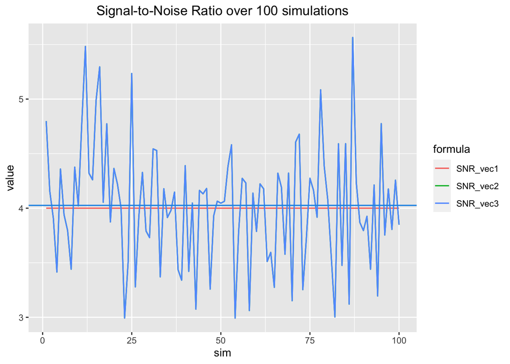

```r
set.seed(2907)
n = 100
p = 50
options.corr = 1
options.R2 = 0.8 # SNR = 4
options.epsilon = 0
options.rho = 0.4

df <- GenRegr(n, p, options)

y <- df$y
X <- df$x
beta_true <-  df$beta
C <- df$C
sigmasq <- df$sigmasq

# library(GGally)
# ggcorr(X, palette = "RdBu", label = FALSE)
#
# library(ggcorrplot)
# corr <- round(cor(X), 1)
# ggcorrplot(corr, hc.order = TRUE, outline.col = "white")
# ggcorrplot(C, hc.order = TRUE, outline.col = "white")


Nsim = 100
SNR_vec1 <- rep(NA,Nsim)
SNR_vec2 <- rep(NA,Nsim)
SNR_vec3 <- rep(NA,Nsim)

for (sim in 1 : Nsim)
{
  df <- GenRegr(n, p, options)
  set.seed(sim)
  y <- df$y
  X <- df$x
  beta_true <-  df$beta
  C <- df$C
  SNR_vec1[sim] <-  t(beta_true)%*%C%*%beta_true/sigmasq #sum((chol(C)%*%beta_true)^2)
  SNR_vec2[sim] <- var(X%*%beta_true)/sigmasq
  SNR_vec3[sim] <- t(beta_true)%*%t(X)%*%X%*%beta_true/(n-1)/sigmasq
}

# SNR_vec1
# SNR_vec2
# SNR_vec3
# SNR_vec2 == SNR_vec3
# SNR_vec1
# mean(SNR_vec2)

library(tidyverse)
df <- data.frame(sim = 1:Nsim,SNR_vec1,SNR_vec2,SNR_vec3)
df_long <- gather(df, formu, value, -c("sim"))

ggplot(df_long, aes(x = sim, y = value, group = formu)) +
  geom_line(aes(color = formu), size = 0.6) +
  geom_hline(yintercept = mean(SNR_vec2), col = 4, size = 0.6) +
  ggtitle("Signal-to-Noise Ratio over 100 simulations") +
  theme(plot.title = element_text(hjust = 0.5)) +
  labs(color = "formula")
```

**Conclusion:** Formula 2 and 3 are equivalent.

**Theorem**

If $\beta$ is a vector and $X$ is a random vector with mean $\mu$ and variance $\Sigma$ then

$$\mathbbm E(\beta^TX) = \beta^T\mu \quad \text{and} \quad \mathbbm V(\beta^TX) = \beta^T\Sigma\beta$$

If $B$ is a matrix then

$$\mathbbm E(BX) = B\mu \quad \text{and} \quad \mathbbm V(BX) = B\Sigma ^TB$$

- Choice of priors (and hyper-parameters)
  - https://duongtrinh.shinyapps.io/KST-priors/